# Parte A

Micaela Del Longo @MicaKil

# Librerías

```r
library(dplyr)
```

```r
library(ggplot2)
library(tidyr)
library(rpart)
library(caret)
```

Antes de realizar un primer envío se deben realizar las siguientes actividades:

# Ejercicio 1

Dado el archivo arbolado-mendoza-dataset.csv, seleccionar de manera uniformemente aleatoria el 20% del conjunto de datos y crear un nuevo archivo con el nombre de arbolado-mendoza-dataset-validation.csv y el 80% restante con el nombre de arbolado-mendoza-dataset-train.csv

```r
data <- read.csv("../data/arbolado-mza-dataset.csv")

num_rows <- nrow(data)

# define la proporción para dividir los datos (80% de entrenamiento, 20% de validación)
training_proportion <- 0.8

# calcula el número de filas para los datos de entrenamiento y validación
training_number <- round(num_rows * training_proportion)
validation_number <- num_rows - training_number

# genera un conjunto de índices aleatorios sin reemplazo (por default replace=FALSE) para las filas de validación
validation_indices <- sample(1:num_rows, validation_number)

# divide los datos en conjuntos de entrenamiento y validación
training_data <- data[-validation_indices, ]  # el operador "-" indica que se excluyen los índices de validación
validation_data <- data[validation_indices, ]

# write.csv(datos_entrenamiento, "arbolado-mendoza-dataset-train.csv", row.names = FALSE)
# write.csv(datos_validacion, "arbolado-mendoza-dataset-validation.csv", row.names = FALSE)
```

# Ejercicio 2

A partir del archivo arbolado-mendoza-dataset-train.csv responder las siguientes preguntas:

1. ¿Cuál es la distribución de la clase inclinacion_peligrosa?
2. ¿Se puede considerar alguna sección más peligrosa que otra?
3. ¿Se puede considerar alguna especie más peligrosa que otra?

**IMPORTANTE:** para responder cada una de estas preguntas se deberá generar una visualización/gráfico que justifique la respuesta.

```r
data <- read.csv("../data/arbolado-mendoza-dataset-train.csv")
```

## Pregunta 1: ¿Cuál es la distribución de la clase inclinacion_peligrosa?

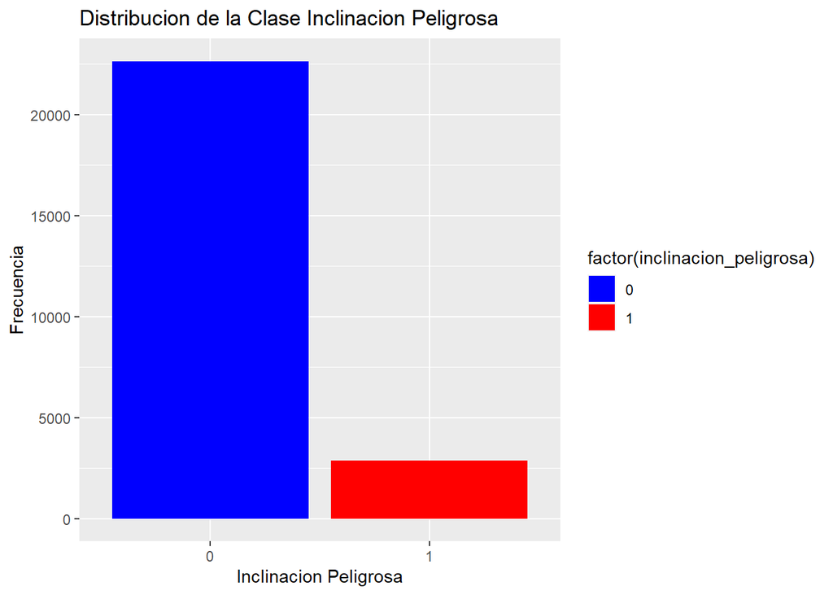

```r
ggplot(data, aes(x = factor(inclinacion_peligrosa), fill = factor(inclinacion_peligrosa))) +
    geom_bar() +
    scale_fill_manual(values = c("blue", "red")) + # asigna colores a las barras
    labs(x = "Inclinacion Peligrosa", y = "Frecuencia") +
    ggtitle("Distribucion de la Clase Inclinacion Peligrosa")
```

```r
# ggsave("pics/2_1_distribucion_inclinacion_peligrosa.png", plot = last_plot(), width = 6, height = 4)
```

## Pregunta 2: ¿Se puede considerar alguna sección más peligrosa que otra?

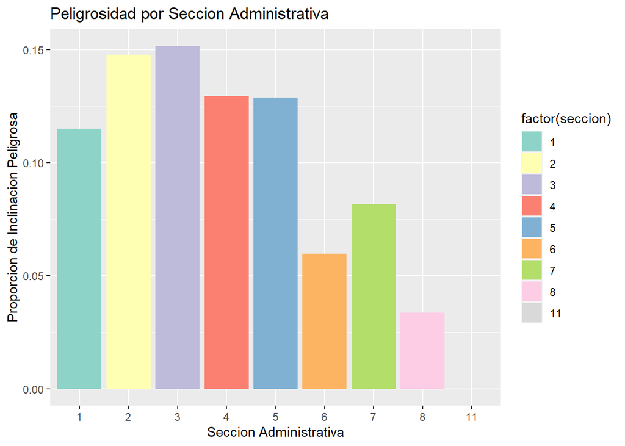

```r
# crea un nuevo conjunto de datos "secciones_peligrosas" con resumen de peligrosidad por sección
secciones_peligrosas <- data %>%
    group_by(seccion) %>%  # agrupar por sección
    # resumen de peligrosidad por sección -> total_count = n() calcula el número total de filas en cada grupo
    summarize(peligrosa_count = sum(inclinacion_peligrosa == 1), total_count = n()) %>%
    # mutate agrega una nueva columna peligrosidad la cual se calcula dividiendo peligrosa_count entre total_count
    mutate(peligrosidad = peligrosa_count / total_count)

ggplot(secciones_peligrosas, aes(x = factor(seccion), y = peligrosidad, fill = factor(seccion))) +
    geom_bar(stat = "identity") +  # representa las alturas de las barras tal como se proporcionan en los datos
    scale_fill_brewer(palette = "Set3") +
    labs(x = "Seccion Administrativa", y = "Proporcion de Inclinacion Peligrosa") +
    ggtitle("Peligrosidad por Seccion Administrativa")
```

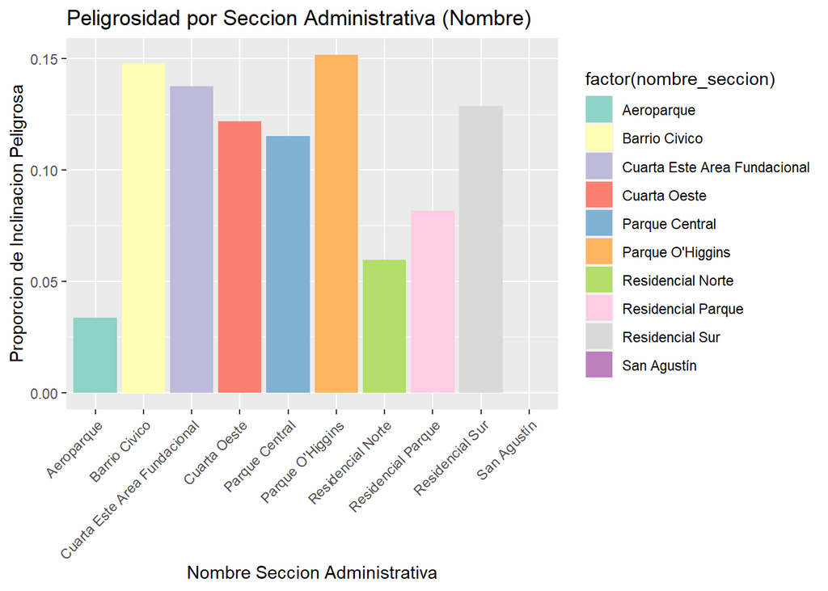

```r
#ggsave("pics/2_2_peligrosidad_secciones.png", plot = last_plot(), width = 8, height = 6)

nombre_secciones_peligrosas <- data %>%
    group_by(nombre_seccion) %>%
    # resumen de peligrosidad por sección -> total_count = n() calcula el número total de filas en cada grupo
    summarize(peligrosa_count = sum(inclinacion_peligrosa == 1), total_count = n()) %>%
    # mutate agrega una nueva columna peligrosidad la cual se calcula dividiendo peligrosa_count entre total_count
    mutate(peligrosidad = peligrosa_count / total_count)

ggplot(nombre_secciones_peligrosas, aes(x = factor(nombre_seccion), y = peligrosidad, fill = factor(nombre_seccion))) +
    geom_bar(stat = "identity") +  # representa las alturas de las barras tal como se proporcionan en los datos
    scale_fill_brewer(palette = "Set3") +
    labs(x = "Nombre Seccion Administrativa", y = "Proporcion de Inclinacion Peligrosa") +
    ggtitle("Peligrosidad por Seccion Administrativa (Nombre)") +
    theme(axis.text.x = element_text(angle = 45, hjust = 1))
```

```r
#ggsave("pics/2_2_peligrosidad_nombre_secciones.png", plot = last_plot(), width = 8, height = 6)
```

## Pregunta 3: ¿Se puede considerar alguna especie más peligrosa que otra?

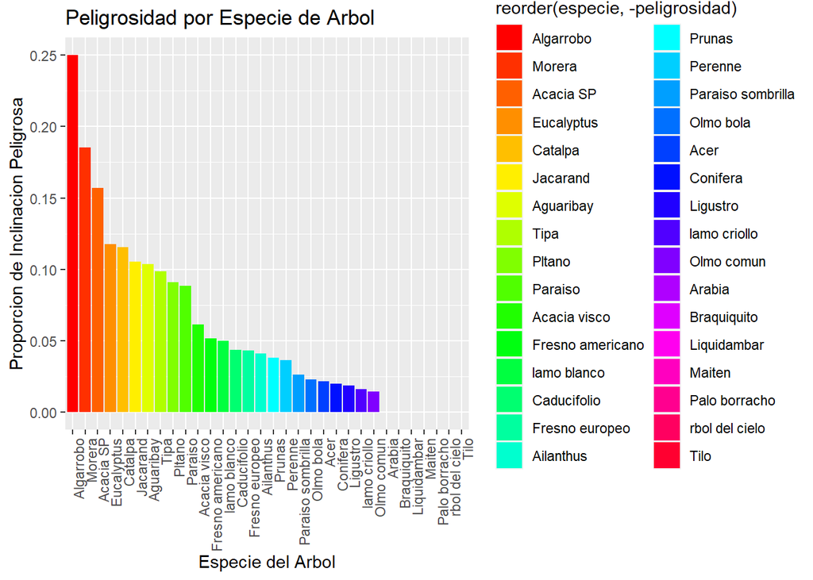

```r
# crea un nuevo conjunto de datos "especies_peligrosas" con resumen de peligrosidad por especie
especies_peligrosas <- data %>%
    group_by(especie) %>%  # agrupa por especie
    summarize(peligrosa_count = sum(inclinacion_peligrosa == 1), total_count = n()) %>%
    mutate(peligrosidad = peligrosa_count / total_count)

ggplot(especies_peligrosas, aes(x = reorder(especie, -peligrosidad), y = peligrosidad, fill = reorder(especie, -peligrosidad))) +
    geom_bar(stat = "identity") +
    scale_fill_manual(values = rainbow(length(unique(especies_peligrosas$especie)))) +
    labs(x = "Especie del Arbol", y = "Proporcion de Inclinacion Peligrosa") +
    ggtitle("Peligrosidad por Especie de Arbol") +
    theme(axis.text.x = element_text(angle = 90, hjust = 1))
```

```r
#ggsave("pics/2_3_peligrosidad_especies.png", plot = last_plot(), width = 8, height = 6)
```

# Ejercicio 3

A partir del archivo arbolado-mendoza-dataset-train.csv:

## Ejercicio 3.1

Generar un histograma de frecuencia para la variable circ_tronco_cm. Probar con diferentes números de bins.

```r
trees <- read.csv("../data/arbolado-mendoza-dataset-train.csv")
```

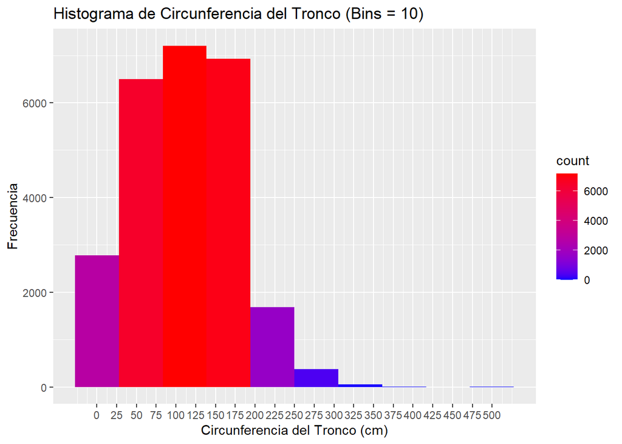

```r
ggplot(trees, aes(x = circ_tronco_cm)) +
    geom_histogram(bins = 10, aes(fill = after_stat(count))) +
    scale_fill_gradient(low = "blue", high = "red") +
    labs(title = "Histograma de Circunferencia del Tronco (Bins = 10)", x = "Circunferencia del Tronco (cm)", y = "Frecuencia") +
    scale_x_continuous(breaks = seq(0, max(trees$circ_tronco_cm), by = 25))
```

```r
# ggsave("pics/3_1_histograma_circ_tronco_bins_10.png", plot = last_plot(), width = 8, height = 6)
```

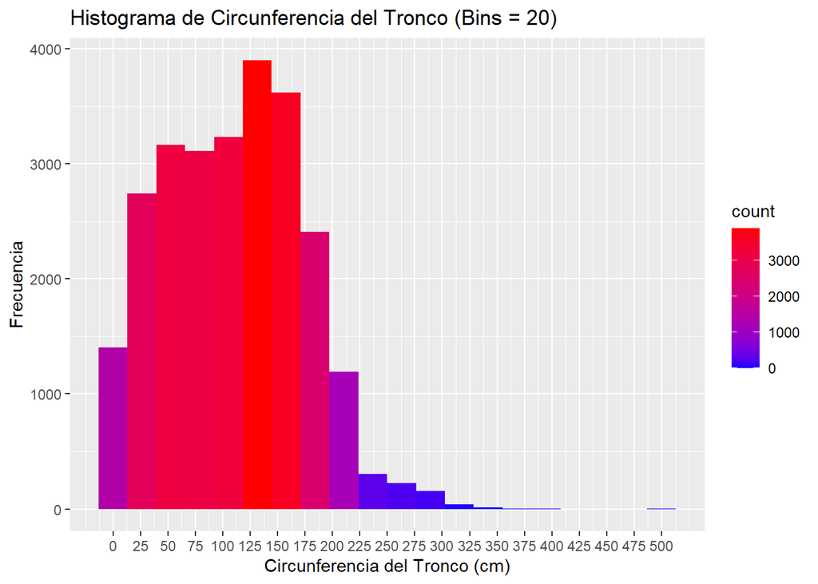

```r
ggplot(trees, aes(x = circ_tronco_cm)) +
    geom_histogram(bins = 20, aes(fill = after_stat(count))) +
    scale_fill_gradient(low = "blue", high = "red") +
    labs(title = "Histograma de Circunferencia del Tronco (Bins = 20)", x = "Circunferencia del Tronco (cm)", y = "Frecuencia") +
    scale_x_continuous(breaks = seq(0, max(trees$circ_tronco_cm), by = 25))
```

```r
# ggsave("pics/3_1_histograma_circ_tronco_bins_20.png", plot = last_plot(), width = 8, height = 6)
```

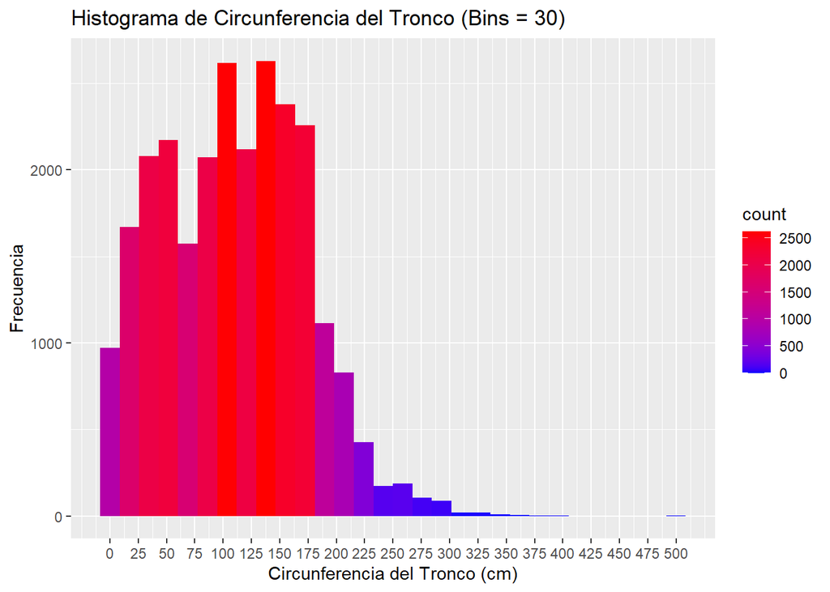

```r
ggplot(trees, aes(x = circ_tronco_cm)) +
    geom_histogram(bins = 30, aes(fill = after_stat(count))) +
    scale_fill_gradient(low = "blue", high = "red") +
    labs(title = "Histograma de Circunferencia del Tronco (Bins = 30)", x = "Circunferencia del Tronco (cm)", y = "Frecuencia") +
    scale_x_continuous(breaks = seq(0, max(trees$circ_tronco_cm), by = 25))
```

```r
# ggsave("pics/3_1_histograma_circ_tronco_bins_30.png", plot = last_plot(), width = 8, height = 6)
```

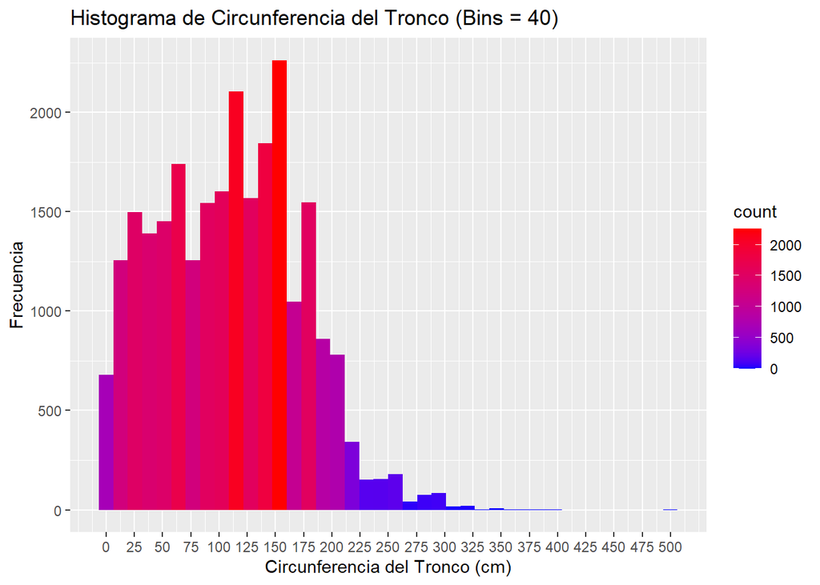

```r
ggplot(trees, aes(x = circ_tronco_cm)) +
    geom_histogram(bins = 40, aes(fill = after_stat(count))) +
    scale_fill_gradient(low = "blue", high = "red") +
    labs(title = "Histograma de Circunferencia del Tronco (Bins = 40)", x = "Circunferencia del Tronco (cm)", y = "Frecuencia") +
    scale_x_continuous(breaks = seq(0, max(trees$circ_tronco_cm), by = 25))
```

```r
# ggsave("pics/3_1_histograma_circ_tronco_bins_40.png", plot = last_plot(), width = 8, height = 6)
```

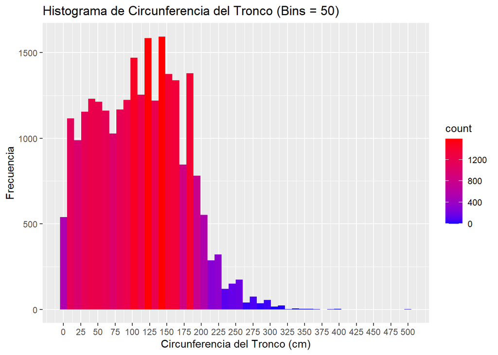

```r
ggplot(trees, aes(x = circ_tronco_cm)) +
    geom_histogram(bins = 50, aes(fill = after_stat(count))) +
    scale_fill_gradient(low = "blue", high = "red") +
    labs(title = "Histograma de Circunferencia del Tronco (Bins = 50)", x = "Circunferencia del Tronco (cm)", y = "Frecuencia") +
    scale_x_continuous(breaks = seq(0, max(trees$circ_tronco_cm), by = 25))
```

```r
# ggsave("pics/3_1_histograma_circ_tronco_bins_50.png", plot = last_plot(), width = 8, height = 6)
```

## Ejercicio 3.2

Repetir el punto 1) pero separando por la clase de la variable inclinación_peligrosa.

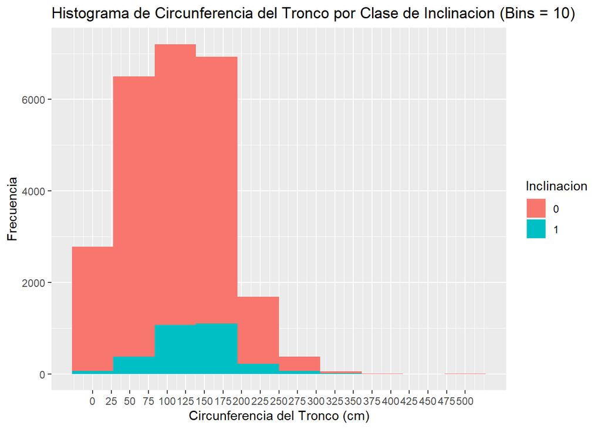

```r
ggplot(trees, aes(x = circ_tronco_cm, fill = factor(inclinacion_peligrosa))) +
    geom_histogram(bins = 10) +
    labs(title = "Histograma de Circunferencia del Tronco por Clase de Inclinacion (Bins = 10)", x = "Circunferencia del Tronco (cm)", y = "Frecuencia") +
    scale_fill_discrete(name = "Inclinacion") +
    scale_x_continuous(breaks = seq(0, max(trees$circ_tronco_cm), by = 25))
```

```r
# ggsave("../pics/3_2_histograma_circ_tronco_separado_por_inclinacion_bins_10.png", plot = last_plot(), width = 8, height = 6)
```

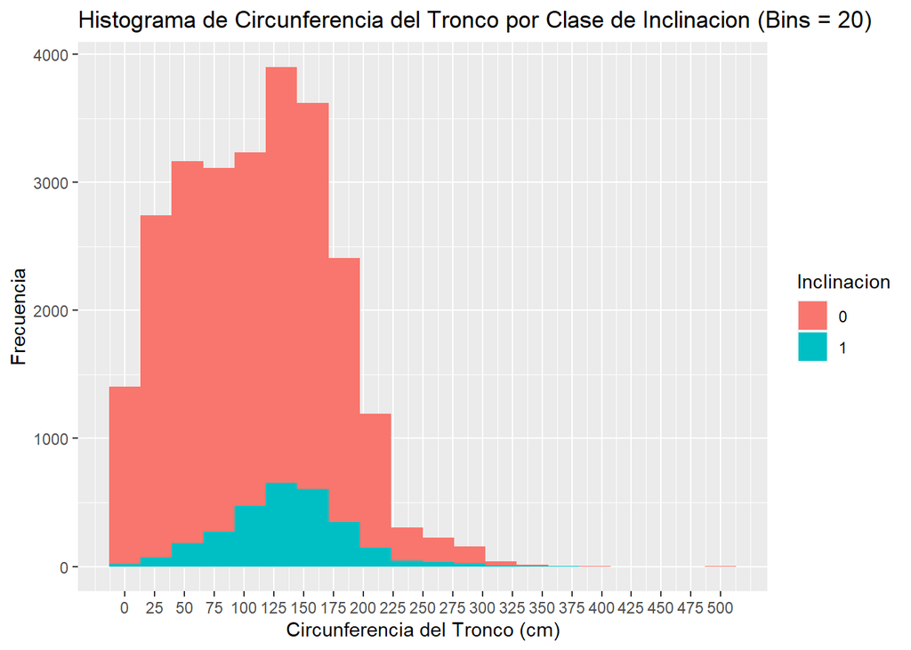

```r
ggplot(trees, aes(x = circ_tronco_cm, fill = factor(inclinacion_peligrosa))) +
    geom_histogram(bins = 20) +
    labs(title = "Histograma de Circunferencia del Tronco por Clase de Inclinacion (Bins = 20)", x = "Circunferencia del Tronco (cm)", y = "Frecuencia") +
    scale_fill_discrete(name = "Inclinacion") +
    scale_x_continuous(breaks = seq(0, max(trees$circ_tronco_cm), by = 25))
```

```r
# ggsave("../pics/3_2_histograma_circ_tronco_separado_por_inclinacion_bins_20.png", plot = last_plot(), width = 8, height = 6)
```

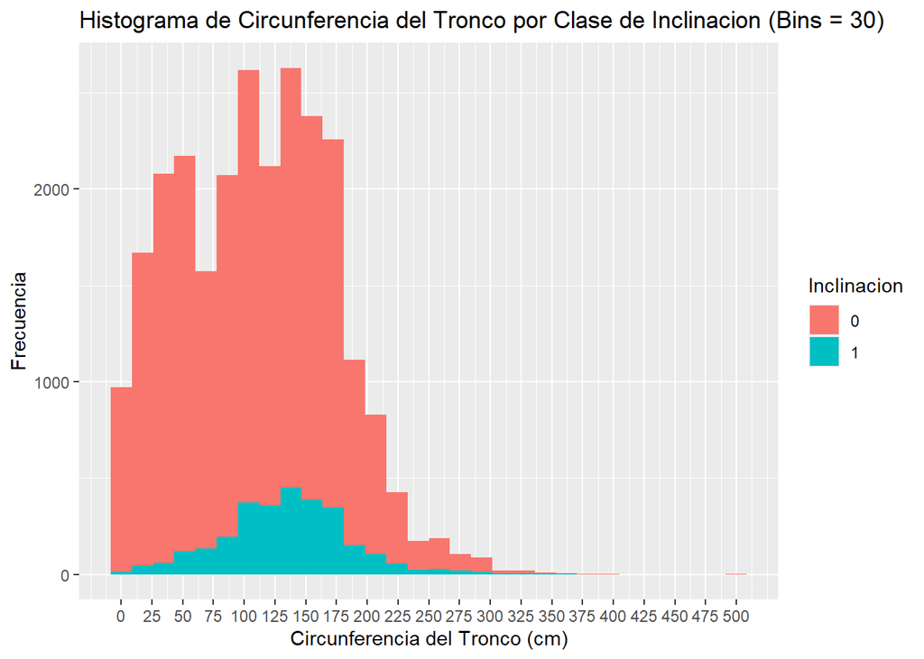

```r
ggplot(trees, aes(x = circ_tronco_cm, fill = factor(inclinacion_peligrosa))) +
    geom_histogram(bins = 30) +
    labs(title = "Histograma de Circunferencia del Tronco por Clase de Inclinacion (Bins = 30)", x = "Circunferencia del Tronco (cm)", y = "Frecuencia") +
    scale_fill_discrete(name = "Inclinacion") +
    scale_x_continuous(breaks = seq(0, max(trees$circ_tronco_cm), by = 25))
```

```r
# ggsave("../pics/3_2_histograma_circ_tronco_separado_por_inclinacion_bins_30.png", plot = last_plot(), width = 8, height = 6)
```

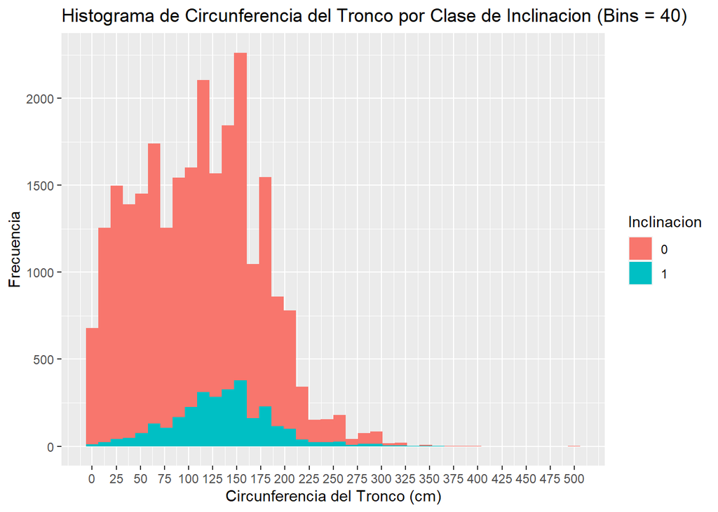

```r
ggplot(trees, aes(x = circ_tronco_cm, fill = factor(inclinacion_peligrosa))) +
    geom_histogram(bins = 40) +
    labs(title = "Histograma de Circunferencia del Tronco por Clase de Inclinacion (Bins = 40)", x = "Circunferencia del Tronco (cm)", y = "Frecuencia") +
    scale_fill_discrete(name = "Inclinacion") +
    scale_x_continuous(breaks = seq(0, max(trees$circ_tronco_cm), by = 25))
```

```r
# ggsave("../pics/3_2_histograma_circ_tronco_separado_por_inclinacion_bins_40.png", plot = last_plot(), width = 8, height = 6)
```

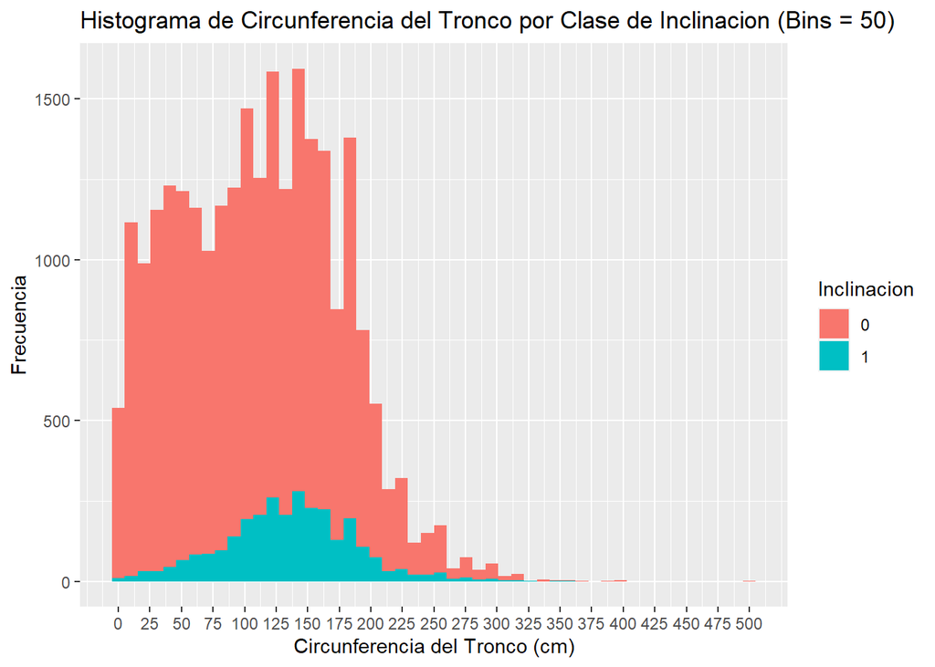

```r
ggplot(trees, aes(x = circ_tronco_cm, fill = factor(inclinacion_peligrosa))) +
    geom_histogram(bins = 50) +
    labs(title = "Histograma de Circunferencia del Tronco por Clase de Inclinacion (Bins = 50)", x = "Circunferencia del Tronco (cm)", y = "Frecuencia") +
    scale_fill_discrete(name = "Inclinacion") +
    scale_x_continuous(breaks = seq(0, max(trees$circ_tronco_cm), by = 25))
```

```r
# ggsave("../pics/3_2_histograma_circ_tronco_separado_por_inclinacion_bins_50.png", plot = last_plot(), width = 8, height = 6)
```

## Ejercicio 3.3

Crear una nueva variable categórica de nombre circ_tronco_cm_cat a partir circ_tronco_cm, en donde puedan asignarse solo 4 posibles valores [muy alto, alto, medio, bajo]. Utilizar la información del punto b para seleccionar los puntos de corte para cada categoría.

```r
trees <- read.csv("../data/arbolado-mendoza-dataset-train.csv")

# calcula los cuartiles de la variable circ_tronco_cm
percentil_25 <- quantile(trees$circ_tronco_cm, 0.25)
percentil_50 <- quantile(trees$circ_tronco_cm, 0.50)
percentil_75 <- quantile(trees$circ_tronco_cm, 0.75)

cuts <- c(0, percentil_25, percentil_50, percentil_75, max(trees$circ_tronco_cm))

tags <- c("bajo", "medio", "alto", "muy alto")

# crea la variable categórica
trees$circ_tronco_cm_cat <- cut(trees$circ_tronco_cm, breaks = cuts, labels = tags, include.lowest = TRUE)
```

## Ejercicio 3.4

Guardar el nuevo dataframe bajo el nombre de arbolado-mendoza-dataset-circ_tronco_cm-train.csv

```r
write.csv(trees, "../data/arbolado-mendoza-dataset-circ_tronco_cm-train.csv", row.names = FALSE)
```

# Ejercicio 4: Clasificador Aleatório

## Ejercicio 4.1

Implementar una función que dado un conjunto de observaciones (data.frame) genere una nueva columna de nombre prediction_prob con un valor aleatorio entre 0 y 1.

```r
agregar_prediccion_aleatoria <- function(data) {
    # genera valores aleatorios entre 0 y 1
    prediction_prob <- runif(nrow(data))

    # agrega la columna "prediction_prob" al data.frame
    data$prediction_prob <- prediction_prob

    # devuelve el data.frame con la nueva columna
    return(data)
}
```

## Ejercicio 4.2

Implementar una función de nombre random_classifier, que reciba como parámetro el dataframe generado con anterioridad y a partir de la columna predictions_prob genere una nueva columna prediction_class bajo el siguiente criterio: `If predictions_prob > 0.5 then prediction_class=1 else prediction_class=0`

La función deberá devolver el dataframe original junto a la nueva columna generada.

```r
random_classifier <- function(data) {
    # crea una nueva columna "prediction_class" basada en "prediction_prob"
    data$prediction_class <- ifelse(data$prediction_prob > 0.5, 1, 0)

    return(data)
}
```

## Ejercicio 4.3

Cargar el archivo arbolado-mendoza-dataset-validation.csv como una data.frame y aplicarle la función random_classifier.

```r
set.seed(123)  # semilla para reproducibilidad
data <- read.csv("../data/arbolado-mendoza-dataset-validation.csv")
random_prediction <- agregar_prediccion_aleatoria(data)
random_prediction <- random_classifier(random_prediction)

# saveRDS(random_prediction_data, "data-frames/random_prediction.rds")
```

## Ejercicio 4.4

A partir de la columna recientemente generada y la columna con la clase (inclinación peligrosa) calcular utilizando lenguaje R (dplyr) el número de:

1. Número de árboles CON inclinación peligrosa que fueron correctamente predichos como peligrosos por el modelo/algoritmo. (True Positive)
2. Número de árboles SIN inclinación peligrosa que fueron correctamente predichos como no peligrosos por el modelo. (True Negative)
3. Número de árboles SIN inclinación peligrosa que fueron incorrectamente predichos como peligrosos según el modelo. (False Positives)
4. Número de árboles CON inclinación peligrosa que fueron incorrectamente predichos como no peligrosos según el modelo. (False Negatives)

El resultado es una tabla que se conoce como matriz de confusión.

```r
create_confusion_matrix <- function(data) {
    TP <- data %>%
        filter(prediction_class == 1 & inclinacion_peligrosa == 1) %>%
        nrow()

    # True Negatives (TN)
    TN <- data %>%
        filter(prediction_class == 0 & inclinacion_peligrosa == 0) %>%
        nrow()

    # False Positives (FP)
    FP <- data %>%
        filter(prediction_class == 1 & inclinacion_peligrosa == 0) %>%
        nrow()

    # False Negatives (FN)
    FN <- data %>%
        filter(prediction_class == 0 & inclinacion_peligrosa == 1) %>%
        nrow()

    confusion_matrix <- data.frame(
        True_Positive = TP,
        True_Negative = TN,
        False_Positive = FP,
        False_Negative = FN
    )

    return(confusion_matrix)
}
```

```r
create_confusion_matrix_tidyr <- function (data){
    confusion_matrix <- data %>%
        group_by(inclinacion_peligrosa, prediction_class) %>%
        summarize(count = n()) %>%
        pivot_wider(names_from = prediction_class, values_from = count) %>%
        replace(is.na(.), 0)  # reemplaza los valores NA por 0

    return(confusion_matrix)
}
```

```r
random_prediction <- readRDS("../data-frames/random_prediction.rds")
random_confusion_matrix <- create_confusion_matrix(random_prediction)
saveRDS(random_confusion_matrix, "../data-frames/random_confusion_matrix.rds")
```

# Ejercicio 5: Clasificador por clase Mayoritaria:

## Ejercicio 5.1

Implementar una función de nombre biggerclass_classifier, que reciba como parámetro el dataframe generado con anterioridad y genere una nueva columna de nombre prediction_class en donde se asigne siempre de la clase mayoritaria.

La función deberá devolver el dataframe original junto a la nueva columna generada.

```r
biggerclass_classifier <- function(data) {
    bigger_class <- data %>%
        group_by(inclinacion_peligrosa) %>%
        summarize(count = n()) %>%
        arrange(desc(count)) %>%  # la clase mayoritaria es la primera
        first() %>%
        pull(inclinacion_peligrosa)

    # agrega la nueva columna prediction_class con la clase mayoritaria
    data <- data %>%
        mutate(prediction_class = bigger_class)

    return(data)
}
```

## Ejercicio 5.2

Repetir los puntos 4.c y 4.d pero aplicando la nueva función biggerclass_classifier

```r
data <- read.csv("../data/arbolado-mendoza-dataset-validation.csv")
biggerclass_prediction <- biggerclass_classifier(data)
saveRDS(biggerclass_prediction, "../data-frames/biggerclass_prediction.rds")
```

```r
biggerclass_prediction <- readRDS("../data-frames/biggerclass_prediction.rds")
biggerclass_confusion_matrix <- create_confusion_matrix(biggerclass_prediction)
saveRDS(biggerclass_confusion_matrix, "../data-frames/biggerclass_confusion_matrix.rds")
```

# Ejercicio 6

A partir de una matriz de confusión es posible calcular distintas métricas que nos permiten determinar la calidad del modelo de clasificación.

```r
calculate_metrics <- function(confusion_matrix){
    # alias para confusion matrix
    TP <- confusion_matrix$True_Positive
    TN <- confusion_matrix$True_Negative
    FP <- confusion_matrix$False_Positive
    FN <- confusion_matrix$False_Negative

    sensitivity <- TP / (TP + FN)
    specificity <- TN / (TN + FP)
    precision <- TP / (TP + FP)
    negative_predictive_value <- TN / (TN + FN)
    accuracy <- (TP + TN) / (TP + TN + FP + FN)

    metrics <- data.frame(
        Sensitivity = sensitivity,
        Specificity = specificity,
        Precision = precision,
        Negative_Predictive_Value = negative_predictive_value,
        Accuracy = accuracy
    )

    return(metrics)
}
```

```r
random_confusion_matrix <- readRDS("../data-frames/random_confusion_matrix.rds")
random_metrics <- calculate_metrics(random_confusion_matrix)
saveRDS(random_metrics, "../data-frames/random_metrics.rds")
print(random_metrics)
```

```
##   Sensitivity Specificity Precision Negative_Predictive_Value  Accuracy
## 1   0.4920863   0.5020222 0.1077505                 0.8899626 0.5009401
```

```r
biggerclass_confusion_matrix <- readRDS("../data-frames/biggerclass_confusion_matrix.rds")
biggerclass_metrics <- calculate_metrics(biggerclass_confusion_matrix)
saveRDS(biggerclass_metrics, "../data-frames/biggerclass_metrics.rds")
print(biggerclass_metrics)
```

```
##   Sensitivity Specificity Precision Negative_Predictive_Value Accuracy
## 1           0           1       NaN                    0.8911   0.8911
```

# Ejercicio 7: Validación Cruzada (Cross Validation) (k-folds)

La validación cruzada es una técnica para estimar el error de generalización de un algoritmo/modelo de machine learning. La técnica consiste en (previo realizar una mezcla aleatoria) separar el conjunto de datos en k partes (normalmente denominadas folds). Luego en la primera iteración se utilizan k-1 partes para entrenar E1 y se utiliza la restante para test. El proceso se repite por k iteraciones utilizando en cada una diferentes conjuntos de entrenamiento y test.

## Ejercicio 7.1

Crear una función de nombre create_folds() que reciba como parámetro un dataframe y la cantidad de folds y devuelva una lista de R con la siguiente estructura: `list(Fold1=c(...), Fold2=c(..),... Fold10=c())`. Donde Fold1 va a contender los índices del dataframe que fueron seleccionados para el primer fold, y así con los demás.

```r
create_folds <- function (data, num_folds) {
  num_rows <- nrow(data)

  # mezcla aleatoriamente los índices de las filas
  set.seed(123)  # para hacer la mezcla reproducible
  shuffled_indices <- sample(1:num_rows)

  # tamaño de cada fold
  fold_size <- floor(num_rows / num_folds)

  # lista para almacenar los índices de los folds
  folds_list <- list()

  # crea los folds
  for (i in 1:num_folds) {
    # calcula los índices del fold actual
    start_index <- (i - 1) * fold_size + 1
    end_index <- min(i * fold_size, num_rows)
    fold_indices <- shuffled_indices[start_index:end_index]

    # almacena los índices
    fold_name <- paste0("Fold", i)
    folds_list[[fold_name]] <- fold_indices
  }

  return(folds_list)
}
```

## Ejercicio 7.2

Crear una función de nombre cross_validation() que reciba como parámetro una data frame y un número de folds y entrene un modelo de árbol de decisión (utilizar paquete rpart) para cada uno de los posibles conjuntos de entrenamiento y calcule las métricas: *Accuracy, Precision, Sensitivity, Specificity* para cada uno de los posibles conjuntos de tests. Devolver media y desviación estándar.

```r
# library(rpart)
# train_formula<-formula(inclinacion_peligrosa~altura+
#     Circ_tronco_cm+
#     Lat+long+
#     Seccion+
#     especie)
# generamos el modelo
# tree_model<-rpart(train_formula,data=data_train)
# obtenemos la predicción
# p<-predict(tree_model,data_val,type='class')
```

```r
cross_validation <- function(data, num_folds) {
    folds <- create_folds(data, num_folds)

    # almacenar las métricas
    accuracy_vector <- NULL
    precision_vector <- NULL
    sensitivity_vector <- NULL
    specificity_vector <- NULL

    for (i in 1:num_folds) {
        train_indices <- setdiff(seq_len(nrow(data)), folds[[i]])
        train_data <- data[train_indices, ]
        test_data <- data[folds[[i]], ]

        train_data$inclinacion_peligrosa <- factor(train_data$inclinacion_peligrosa)

        train_data$especie <- factor(train_data$especie, levels = levels(data$especie))
        test_data$especie <- factor(test_data$especie, levels = levels(data$especie))

        train_formula <- formula(inclinacion_peligrosa ~ altura + circ_tronco_cm + lat + long + seccion + especie)
        model <- rpart(train_formula, data = train_data)
        predictions <- predict(model, test_data, type = "class")

        # cálculo de métricas
        confusion_matrix <- confusionMatrix(predictions, as.factor(test_data$inclinacion_peligrosa))
        accuracy_vector <- c(accuracy_vector, confusion_matrix$overall["Accuracy"])
        precision_vector <- c(precision_vector, confusion_matrix$byClass["Pos_Prediction"])
        sensitivity_vector <- c(sensitivity_vector, confusion_matrix$byClass["Sensitivity"])
        specificity_vector <- c(specificity_vector, confusion_matrix$byClass["Specificity"])
    }

    # media y desviación estándar
    metrics_mean <- c(
    Accuracy = mean(accuracy_vector),
    Precision = mean(precision_vector),
    Sensitivity = mean(sensitivity_vector),
    Specificity = mean(specificity_vector)
    )

    metrics_sd <- c(
        Accuracy = sd(accuracy_vector),
        Precision = sd(precision_vector),
        Sensitivity = sd(sensitivity_vector),
        Specificity = sd(specificity_vector)
    )

    return(list(Mean = metrics_mean, SD = metrics_sd))
}
```

```r
data_train <- read.csv("../data/arbolado-mendoza-dataset-train.csv")
data_train$ultima_modificacion <- NULL
data_train$area_seccion <- NULL
metrics <- cross_validation(data_train, 10)
metrics
```

```
## $Mean
##    Accuracy   Precision Sensitivity Specificity
##   0.8870349          NA   1.0000000   0.0000000
##
## $SD
##    Accuracy   Precision Sensitivity Specificity
##  0.00503041          NA  0.00000000  0.00000000
```